# ChIP-Seq Report of Sample QC and Alignment Summary Statistics for GSE95632

Mengyuan Kan (mengykan@upenn.edu)

29 November, 2018

**Project:** GSE95632

**Genome:** For human, the hg38 assembly was used. We estimate the number of rRNA reads as those mapped to chrM plus chrUn_GL000220v1, corresponding to 12S, 16S and 5.8S rRNA. The ‘Other’ category contains all other chr*random and chrUn* available.

**Informatics tools used:**

- Trimmomatic (0.32)
- FastQC (0.11.7)
- BWA (0.7.10-r789)
- samtools (1.8)
- bamtools (2.3.0)
- Picard Tools (1.96)

For each sample, the following programs were run to generate the data necessary to create this report. Written as for unstranded paired-end data. For single-end reads, R2s and insert size metrics would be omitted.

> java -Xmx1024m TrimmomaticPE -phred33 [raw_sample_R1] [raw_sample_R2] [sample_R1] [sample_R1_unpaired] [sample_R2] [sample_R2_unpaired] HEADCROP:[bases to trim, if any] ILLUMINACLIP:[sample_primer_fasta]:2:30:10 MINLEN:50  
> fastqc [sample_R1] [sample_R2]  
> cat [sample_R1/R2] | awk ’((NR-2)%4==0){read=$1;total++;count[read]++}END{for(read in count){if(count[read]==1){unique++}};print total,unique,unique*100/total}’

The bwa-mem is used for alignment, and the outputs are piped into samtools for sorting and indexing:

> bwa-mem –t 12 BWA_index_prefix [sample_R1 fastq file] [sample_R2 fastq file] | view -S -b - | samtools sort @12 -T [sample.tmp] -o [sample.bam] -

Obtain QC metrics from aligned output files [sample].bam:

> samtools idxstats accepted_hits.sorted.bam > accepted_hits.sorted.stats  
> bamtools stats -in accepted_hits.sorted.bam > accepted_hits.sorted.bamstats  
> java -Xmx2g -jar CollectInsertSizeMetrics.jar HISTOGRAM_FILE=InsertSizeHist.pdf INPUT=accepted_hits.sorted.bam OUTPUT=InsertSizeMetrics

Use macs2 for peak calling:

> macs2 callpeak -c [DNA input sample].bam -t [sample].bam -n GR_1D –outdir [sample] -f BAM -g hs -B -q 0.01

## Summary Read Numbers

The number of raw reads correspond to those that passed Casava QC filters, were trimmed to remove adaptors by Trimmomatic, and were aligned by BWA to ref_genome. Unique read counts were obtained by using awk on trimmed fastq files. FastQC estimates of percentage of sequences remaining after deduplication were retrieved from fastqc_data.txt files. Bamtools statistics were based on sorted and indexed bam files. The mapped reads were those that mapped to reference and were output by BWA to [sample].bam. Some reads may be mapped to multiple locations in the genome so that the number of total reads reported by bamstats may be greater than the number of raw reads. Related text files that were saved:

GSE95632 _read_counts.txt

GSE95632 _duplicates.txt

GSE95632 _unique_counts.txt

GSE95632 _bamstats_counts.txt

### Total Number of Raw Reads Summary

| Sample | Raw_Reads | Unique_Reads | Percent_Unique | Fastqc_Total_Duplicate_Estimate |
| --- | --- | --- | --- | --- |
| SRR5309351 | 18464610 | 14420218 | 78.1 | 88.12 |
| SRR5309352 | 41714932 | 35135869 | 84.23 | 90.6 |
| SRR5309353 | 17485091 | 14141364 | 80.88 | 89.68 |
| SRR5309354 | 18173443 | 15486250 | 85.21 | 92.12 |
| SRR5309355 | 78548415 | 70749025 | 90.07 | 93.32 |
| SRR5309356 | 18571778 | 15614408 | 84.08 | 91.26 |
| SRR5309361 | 22377383 | 19661575 | 87.86 | 93.38 |
| SRR5309362 | 28129232 | 24980415 | 88.81 | 93.89 |
| SRR5309363 | 26039965 | 23376490 | 89.77 | 94.33 |
| SRR5309364 | 32657702 | 28245725 | 86.49 | 92.52 |

### Plot: Percentage of Unique Reads in Original Fastq File

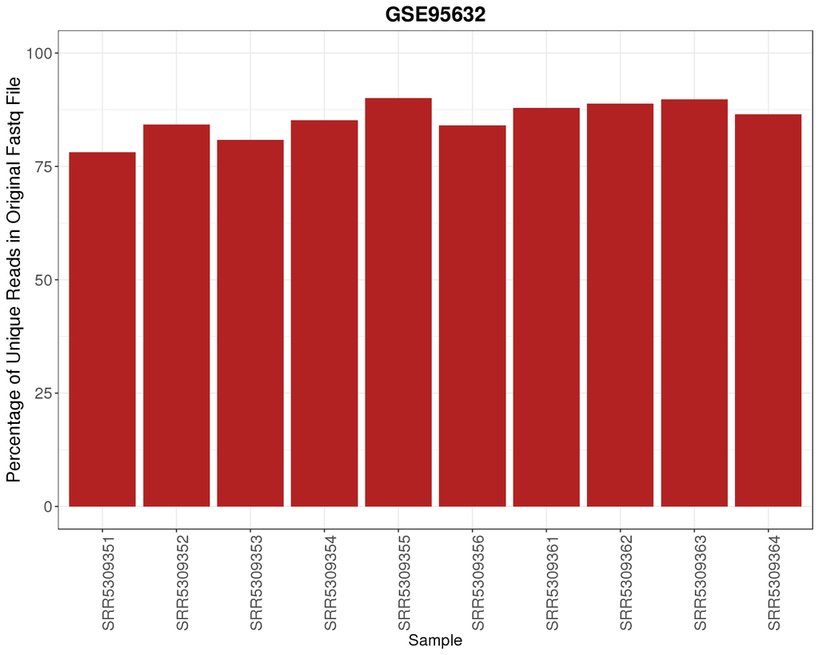

### Plot: Sequence Duplication Level

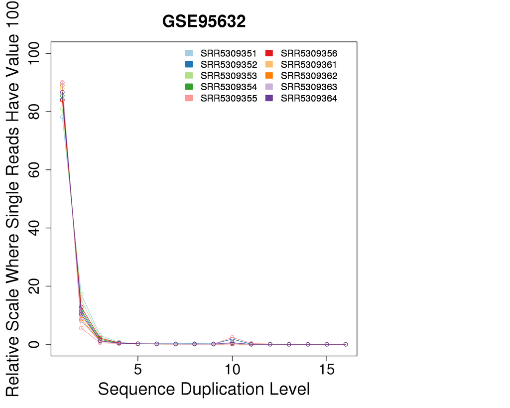

### Bamtools Reads Summary

|  | SRR5309351 | SRR5309352 | SRR5309353 | SRR5309354 | SRR5309355 | SRR5309356 | SRR5309361 | SRR5309362 | SRR5309363 | SRR5309364 |
| --- | --- | --- | --- | --- | --- | --- | --- | --- | --- | --- |
| Total reads | 18464610 | 41714932 | 17485091 | 18173443 | 78548415 | 18571778 | 22377383 | 28129232 | 26039965 | 32657702 |
| Mapped reads | 18094244 | 41464840 | 17125709 | 17928532 | 78054345 | 18301038 | 22204960 | 27888065 | 25800835 | 32349290 |
| Forward strand | 9420506 | 20979567 | 8920090 | 9211644 | 39518679 | 9421894 | 11270676 | 14183449 | 13138378 | 16477628 |
| Reverse strand | 9044352 | 20736030 | 8565241 | 8962076 | 39030938 | 9150135 | 11107089 | 13946206 | 12901998 | 16180544 |
| Unmapped reads | 370366 | 250092 | 359382 | 244911 | 494070 | 270740 | 172423 | 241167 | 239130 | 308412 |

### Bamtools Reads Summary As Percentage of Mapped Reads

|  | SRR5309351 | SRR5309352 | SRR5309353 | SRR5309354 | SRR5309355 | SRR5309356 | SRR5309361 | SRR5309362 | SRR5309363 | SRR5309364 |
| --- | --- | --- | --- | --- | --- | --- | --- | --- | --- | --- |
| Total reads | 100 | 100 | 100 | 100 | 100 | 100 | 100 | 100 | 100 | 100 |
| Mapped reads | 97.99 | 99.4 | 97.94 | 98.65 | 99.37 | 98.54 | 99.23 | 99.14 | 99.08 | 99.06 |
| Forward strand | 51.02 | 50.29 | 51.02 | 50.69 | 50.31 | 50.73 | 50.37 | 50.42 | 50.45 | 50.46 |
| Reverse strand | 48.98 | 49.71 | 48.99 | 49.31 | 49.69 | 49.27 | 49.64 | 49.58 | 49.55 | 49.55 |
| Unmapped reads | 2.01 | 0.6 | 2.06 | 1.35 | 0.63 | 1.46 | 0.77 | 0.86 | 0.92 | 0.94 |

### Percentage of Mapped/Unmapped Reads

|  | SRR5309351 | SRR5309352 | SRR5309353 | SRR5309354 | SRR5309355 | SRR5309356 | SRR5309361 | SRR5309362 | SRR5309363 | SRR5309364 |
| --- | --- | --- | --- | --- | --- | --- | --- | --- | --- | --- |
| Mapped reads | 97.99 | 99.4 | 97.94 | 98.65 | 99.37 | 98.54 | 99.23 | 99.14 | 99.08 | 99.06 |
| Unmapped reads | 2.01 | 0.6 | 2.06 | 1.35 | 0.63 | 1.46 | 0.77 | 0.86 | 0.92 | 0.94 |

### Plot: Percentage of Mapped/Unmapped Reads

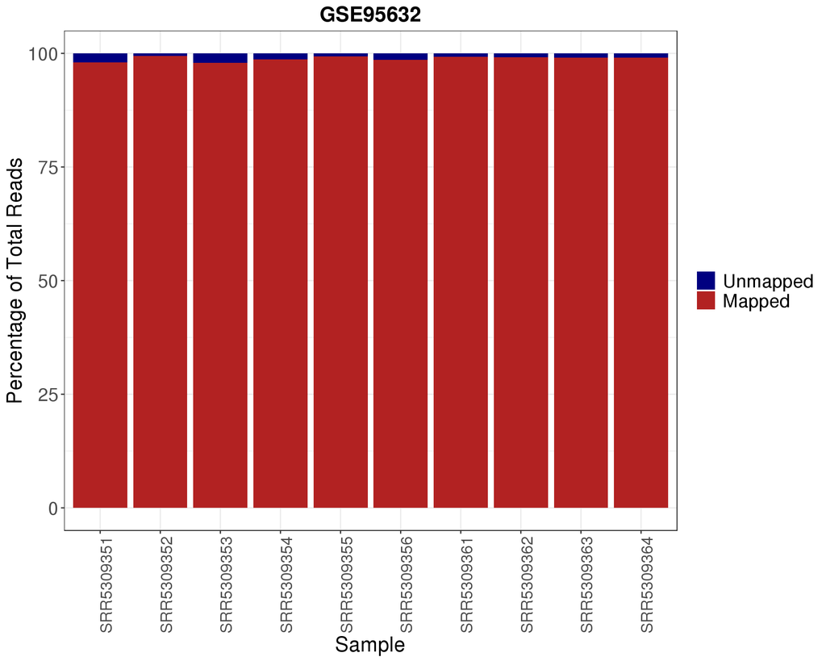

## Reads per Chromosome

Samtools produces a summary document that includes the number of reads mapped to each chromosome. Related text files that were saved:

GSE95632 _counts.txt

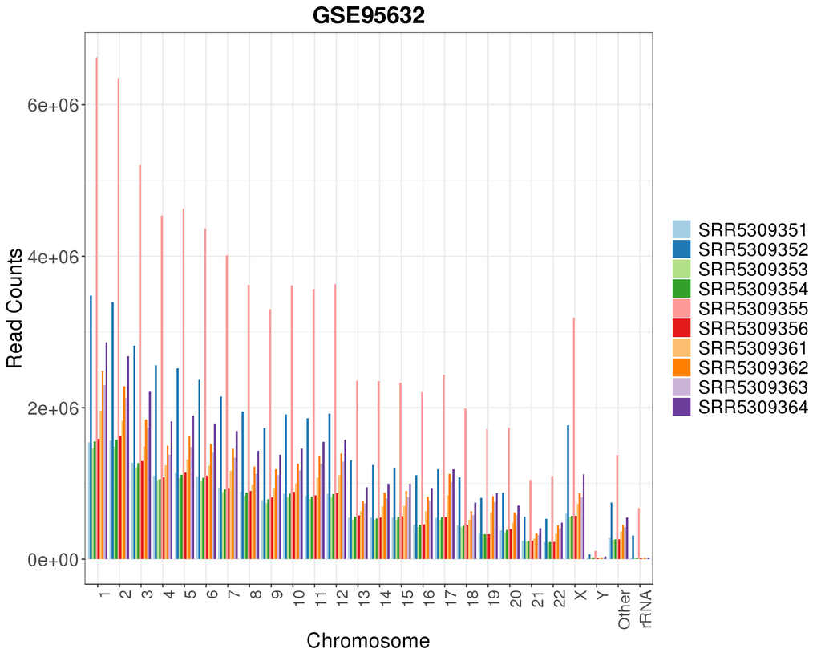

### Mapped Reads to Reference Genome

|  | SRR5309351 | SRR5309352 | SRR5309353 | SRR5309354 | SRR5309355 | SRR5309356 | SRR5309361 | SRR5309362 | SRR5309363 | SRR5309364 |
| --- | --- | --- | --- | --- | --- | --- | --- | --- | --- | --- |
| 1 | 1544125 | 3482882 | 1461922 | 1556319 | 6627048 | 1589067 | 1960188 | 2486075 | 2302920 | 2863401 |
| 2 | 1566220 | 3398356 | 1485783 | 1576533 | 6347668 | 1620806 | 1826700 | 2283118 | 2127942 | 2680482 |
| 3 | 1273646 | 2820407 | 1207551 | 1265317 | 5201987 | 1292629 | 1488820 | 1842452 | 1734978 | 2211064 |
| 4 | 1103732 | 2558473 | 1044794 | 1057941 | 4538533 | 1079524 | 1239977 | 1497313 | 1380583 | 1819737 |
| 5 | 1138473 | 2519889 | 1075317 | 1114157 | 4625198 | 1142603 | 1314669 | 1622802 | 1482527 | 1894299 |
| 6 | 1093358 | 2368758 | 1035848 | 1071895 | 4367985 | 1102613 | 1231690 | 1522485 | 1410347 | 1792111 |
| 7 | 941904 | 2148789 | 890943 | 921010 | 4009485 | 939165 | 1164476 | 1461196 | 1338930 | 1689306 |
| 8 | 886042 | 1949654 | 839842 | 875850 | 3619827 | 900486 | 984692 | 1219785 | 1124999 | 1431077 |
| 9 | 781414 | 1730935 | 738723 | 791314 | 3298287 | 814031 | 941307 | 1188567 | 1109216 | 1379217 |
| 10 | 863561 | 1909287 | 818582 | 864206 | 3618028 | 886279 | 1003152 | 1262227 | 1171937 | 1460420 |

[output cut: 17 more lines]

### Percent of Total Reads Mapped to Reference Genome

|  | SRR5309351 | SRR5309352 | SRR5309353 | SRR5309354 | SRR5309355 | SRR5309356 | SRR5309361 | SRR5309362 | SRR5309363 | SRR5309364 |
| --- | --- | --- | --- | --- | --- | --- | --- | --- | --- | --- |
| 1 | 8.53 | 8.4 | 8.54 | 8.68 | 8.49 | 8.68 | 8.83 | 8.91 | 8.93 | 8.85 |
| 2 | 8.66 | 8.2 | 8.68 | 8.79 | 8.13 | 8.86 | 8.23 | 8.19 | 8.25 | 8.29 |
| 3 | 7.04 | 6.8 | 7.05 | 7.06 | 6.66 | 7.06 | 6.7 | 6.61 | 6.72 | 6.83 |
| 4 | 6.1 | 6.17 | 6.1 | 5.9 | 5.81 | 5.9 | 5.58 | 5.37 | 5.35 | 5.63 |
| 5 | 6.29 | 6.08 | 6.28 | 6.21 | 5.93 | 6.24 | 5.92 | 5.82 | 5.75 | 5.86 |
| 6 | 6.04 | 5.71 | 6.05 | 5.98 | 5.6 | 6.02 | 5.55 | 5.46 | 5.47 | 5.54 |
| 7 | 5.21 | 5.18 | 5.2 | 5.14 | 5.14 | 5.13 | 5.24 | 5.24 | 5.19 | 5.22 |
| 8 | 4.9 | 4.7 | 4.9 | 4.89 | 4.64 | 4.92 | 4.43 | 4.37 | 4.36 | 4.42 |
| 9 | 4.32 | 4.17 | 4.31 | 4.41 | 4.23 | 4.45 | 4.24 | 4.26 | 4.3 | 4.26 |
| 10 | 4.77 | 4.6 | 4.78 | 4.82 | 4.64 | 4.84 | 4.52 | 4.53 | 4.54 | 4.51 |

[output cut: 17 more lines]

## Principal Component Analysis (PCA) Plot

Perform PCA using read scores from DiffBind. DiffBind will compute read counts for all samples. This process takes a while. Use peaks at least shared by two samples.

Compute PCs and variance explained by the first 10 PCs

Variance explained

| PC | Proportion of Variance (%) | Cumulative Proportion of Variance (%) |
| --- | --- | --- |
| PC1 | 93.62 | 93.62 |
| PC2 | 5.581 | 99.2 |
| PC3 | 0.5098 | 99.71 |
| PC4 | 0.1265 | 99.84 |
| PC5 | 0.08805 | 99.93 |
| PC6 | 0.06806 | 100 |
| PC7 | 0.0017 | 100 |
| PC8 | 0.001318 | 100 |

PCA plots are generated using the first two principle components colored by known factors (e.g. treatment/disease conditions, tissue, and donors), visualizing similarities between arrays and these similarities’ correlation to batch effects.

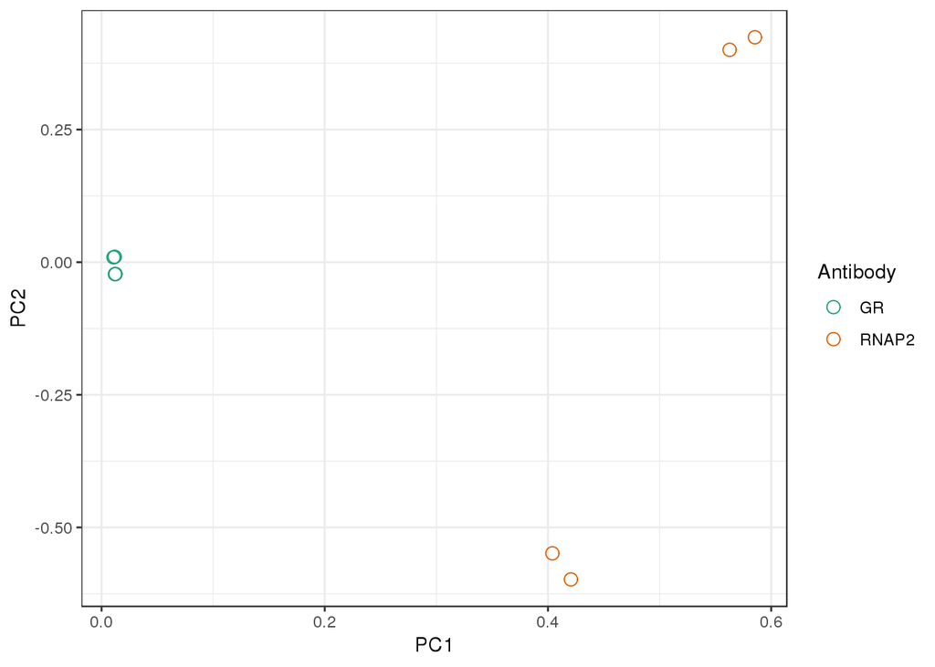

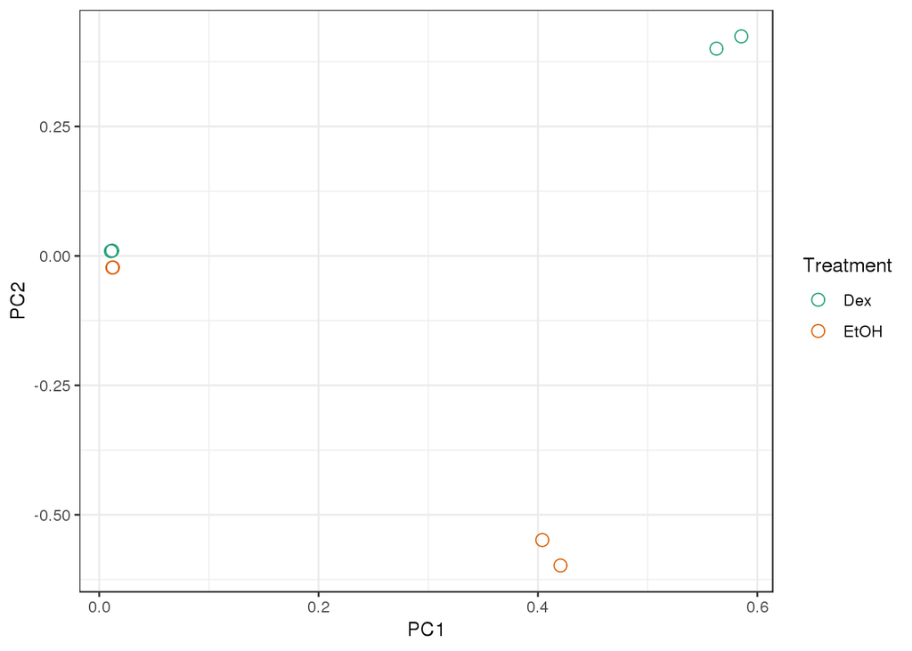

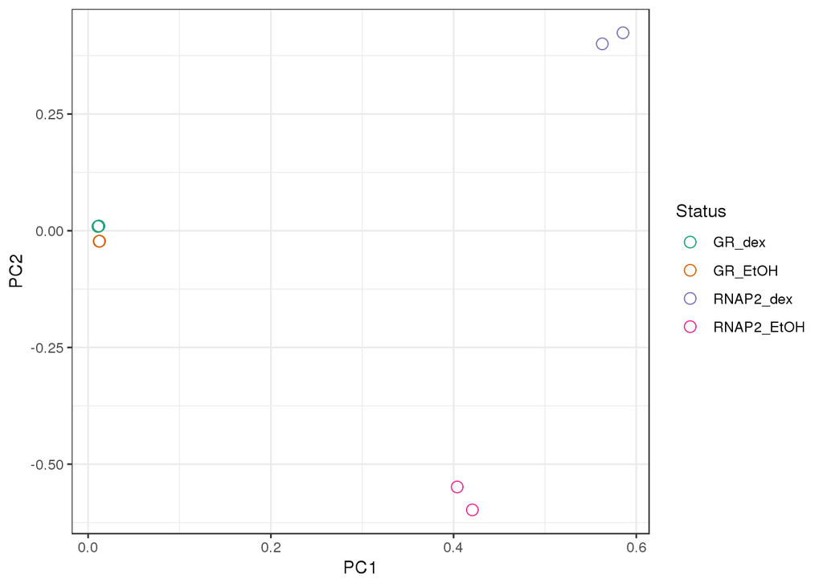

**R version 3.4.3 (2017-11-30)**

**Platform:** x86_64-redhat-linux-gnu (64-bit)

**locale:** *LC_CTYPE=en_US.UTF-8*, *LC_NUMERIC=C*, *LC_TIME=en_US.UTF-8*, *LC_COLLATE=en_US.UTF-8*, *LC_MONETARY=en_US.UTF-8*, *LC_MESSAGES=en_US.UTF-8*, *LC_PAPER=en_US.UTF-8*, *LC_NAME=C*, *LC_ADDRESS=C*, *LC_TELEPHONE=C*, *LC_MEASUREMENT=en_US.UTF-8* and *LC_IDENTIFICATION=C*

**attached base packages:** *parallel*, *stats4*, *stats*, *graphics*, *grDevices*, *utils*, *datasets*, *methods* and *base*

**other attached packages:** *bindrcpp(v.0.2.2)*, *DiffBind(v.2.6.6)*, *SummarizedExperiment(v.1.8.1)*, *DelayedArray(v.0.4.1)*, *matrixStats(v.0.54.0)*, *Biobase(v.2.38.0)*, *GenomicRanges(v.1.30.3)*, *GenomeInfoDb(v.1.14.0)*, *IRanges(v.2.12.0)*, *S4Vectors(v.0.16.0)*, *BiocGenerics(v.0.24.0)*, *pander(v.0.6.1)*, *ggplot2(v.3.0.0)*, *tidyr(v.0.8.1)*, *dplyr(v.0.7.6)*, *DT(v.0.4)*, *RColorBrewer(v.1.1-2)* and *rmarkdown(v.1.9)*

**loaded via a namespace (and not attached):** *amap(v.0.8-16)*, *colorspace(v.1.3-2)*, *rjson(v.0.2.20)*, *hwriter(v.1.3.2)*, *rprojroot(v.1.3-2)*, *XVector(v.0.18.0)*, *base64enc(v.0.1-3)*, *ggrepel(v.0.7.0)*, *bit64(v.0.9-7)*, *AnnotationDbi(v.1.40.0)*, *splines(v.3.4.3)*, *knitr(v.1.20)*, *jsonlite(v.1.5)*, *Rsamtools(v.1.30.0)*, *annotate(v.1.56.2)*, *GO.db(v.3.5.0)*, *pheatmap(v.1.0.10)*, *graph(v.1.56.0)*, *shiny(v.1.1.0)*, *compiler(v.3.4.3)*, *httr(v.1.3.1)*, *GOstats(v.2.44.0)*, *backports(v.1.1.2)*, *assertthat(v.0.2.0)*, *Matrix(v.1.2-12)*, *lazyeval(v.0.2.1)*, *limma(v.3.34.9)*, *later(v.0.7.3)*, *htmltools(v.0.3.6)*, *prettyunits(v.1.0.2)*, *tools(v.3.4.3)*, *gtable(v.0.2.0)*, *glue(v.1.3.0)*, *GenomeInfoDbData(v.1.0.0)*, *Category(v.2.44.0)*, *systemPipeR(v.1.12.0)*, *ShortRead(v.1.36.1)*, *Rcpp(v.0.12.18)*, *Biostrings(v.2.46.0)*, *gdata(v.2.18.0)*, *rtracklayer(v.1.38.3)*, *crosstalk(v.1.0.0)*, *stringr(v.1.3.0)*, *mime(v.0.5)*, *gtools(v.3.5.0)*, *XML(v.3.98-1.10)*, *edgeR(v.3.20.9)*, *zlibbioc(v.1.24.0)*, *scales(v.1.0.0)*, *promises(v.1.0.1)*, *RBGL(v.1.54.0)*, *BBmisc(v.1.11)*, *yaml(v.2.1.18)*, *memoise(v.1.1.0)*, *biomaRt(v.2.34.2)*, *latticeExtra(v.0.6-28)*, *stringi(v.1.2.3)*, *RSQLite(v.2.0)*, *genefilter(v.1.60.0)*, *RMySQL(v.0.10.15)*, *checkmate(v.1.8.5)*, *GenomicFeatures(v.1.30.3)*, *caTools(v.1.17.1)*, *BiocParallel(v.1.12.0)*, *rlang(v.0.2.2)*, *pkgconfig(v.2.0.2)*, *BatchJobs(v.1.7)*, *bitops(v.1.0-6)*, *evaluate(v.0.10.1)*, *lattice(v.0.20-35)*, *purrr(v.0.2.5)*, *bindr(v.0.1.1)*, *GenomicAlignments(v.1.14.2)*, *htmlwidgets(v.1.2)*, *labeling(v.0.3)*, *bit(v.1.1-12)*, *tidyselect(v.0.2.4)*, *GSEABase(v.1.40.1)*, *AnnotationForge(v.1.20.0)*, *plyr(v.1.8.4)*, *magrittr(v.1.5)*, *sendmailR(v.1.2-1)*, *R6(v.2.2.2)*, *gplots(v.3.0.1)*, *DBI(v.0.8)*, *pillar(v.1.2.1)*, *withr(v.2.1.2)*, *survival(v.2.41-3)*, *RCurl(v.1.95-4.10)*, *tibble(v.1.4.2)*, *KernSmooth(v.2.23-15)*, *progress(v.1.1.2)*, *locfit(v.1.5-9.1)*, *grid(v.3.4.3)*, *data.table(v.1.11.4)*, *blob(v.1.1.1)*, *Rgraphviz(v.2.22.0)*, *digest(v.0.6.16)*, *xtable(v.1.8-2)*, *httpuv(v.1.4.3)*, *brew(v.1.0-6)* and *munsell(v.0.5.0)*